The simulated data from Chen, Goldsmith, Ogden 2016 paper is of the form: $y_i(t) = \sum_{j=1}^{p}{x_{ij}\beta_j(t)} + \epsilon_i(t)$ where the first $3$ predictor functions are nonzero and the rest are zero. The errors $\epsilon_i(t)$ are correlated. The function `gen_data_chen_goldsmith_16` by default has correlated errors and `p = 20`.

This is what the data from `gen_data_chen_goldsmith_16` looks like:

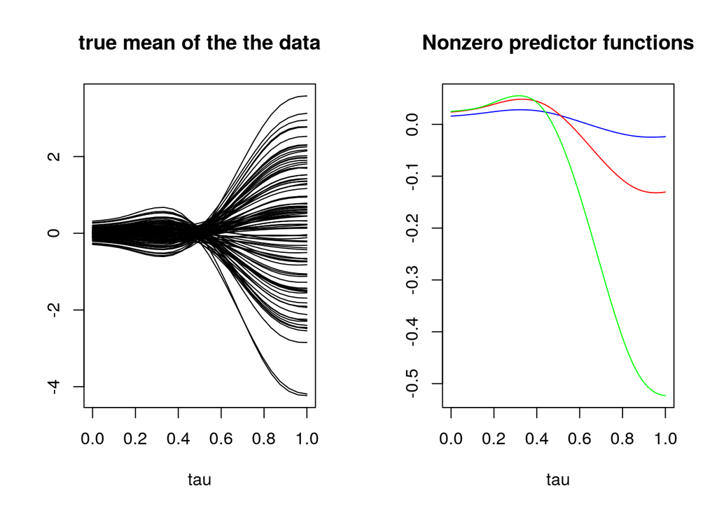

The following metrics are used:

- $\hat{c}_j = min_{\alpha}\{\beta_j \in C_{\alpha}(\hat{\beta}_j)\}$, the minimum $\alpha$ level so that the true predictor function is inside the $1-\alpha$ confidence band
- $MSE$ of the mean of $Y$
- Integral $MSE$ of the predictor functions

Having low values of $\hat{c}_j$ doesn’t necessarily give the better model. But the hope is that the prior will induce shrinkage on the zero predictors. But not too much shrinkage..

Consider the case where $\alpha$ is given a prior that shrinks along the factor dimension and another prior where each element in $\alpha$ is an independent horseshoe.

```
##                 pred_alpha_1 pred_alpha_2 pred_alpha_3 pred_alpha_zeros
## evol_col_shrink        0.720        0.980         0.90        0.3031765
## evol_ind               0.472        0.538         0.82        0.3194118
##                 pred_int_mse_1 pred_int_mse_2 pred_int_mse_3
## evol_col_shrink   0.0004234866    0.001874975    0.002997426
## evol_ind          0.0006096334    0.001321712    0.002850132
##                 pred_int_mse_zeros     mse_Y
## evol_col_shrink       0.0005629018 0.9980121
## evol_ind              0.0008474463 0.9826808
## attr(,"n sample datasets")
## [1] 5
```

(alpha in the output above is referring to significance, not the parameter in the model) The model that shrinks along the factor dimension gives wider credible bands for the true predictors than the independent horseshoe model. The MSEs perform equally well.